# hyd1d - Vignette (DE)

Arnd Weber, Marcus Hatz

26.02.2025

# Das Problem

> Wie erhält man Wasserstandsinformationen für einen Punkt oder eine Strecke an einer Bundeswasserstraße zu einem ausgewählten Zeitpunkt?

## PEGELONLINE

Entlang der Bundeswasserstraßen Deutschlands gibt es eine Vielzahl von Pegelmessstellen. Diese Messstellen werden überwiegend von der Wasserstraßen- und Schifffahrtsverwaltung des Bundes (WSV) betrieben und liefern Wasserstandsmesswerte alle 15 Minuten, in tidebeinflussten Gewässern sogar alle Minute. Für die Öffentlichkeit werden die ungeprüften Messdaten zentral gesammelt und über eine Webseite bis 30 Tage rückwirkend veröffentlicht:

https://pegelonline.wsv.de/gast/start

Durch die manuelle Auswahl entsprechender Pegel von [PEGELONLINE](https://pegelonline.wsv.de/gast/start) lassen sich näherungsweise, flussabschnittsbezogene Wasserstandsentwicklungen beobachten und bewerten, wie hier an den Pegeln [Rosslau](https://pegelonline.wsv.de/gast/stammdaten?pegelnr=501490) und [Dessau](https://pegelonline.wsv.de/gast/stammdaten?pegelnr=502000) zu sehen ist:

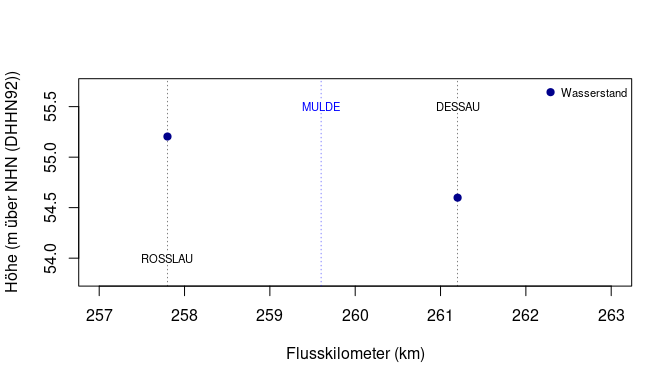

**Abb. 1**: Tagesgemittelte Wasserstände vom 21.12.2016 an der Elbe bei Rosslau und Dessau.

Exakte Informationen sind allerdings nur für die Pegelstandorte verfügbar, was dazu führt, dass beim Risikomanagement im Rahmen der Hochwasservorhersage immer Bezug auf relevante Pegelstände genommen wird, und die Rede ist von:

> Ab einem Wasserstand von X am Pegel Y wird die Schifffahrt eingestellt, werden die Flutschutztore geschlossen, etc.

Wo die Wasserspiegellagen entlang der Gewässerachse - also zwischen den Pegeln - liegen, läßt sich mittels der lokalen Messdaten von [PEGELONLINE](https://pegelonline.wsv.de/gast/start) nicht ermitteln.

## FLYS3

### Entwicklung

Um diese Informationslücke zu schließen und Wasserstandsinformationen für beliebige Orte entlang eines Gewässers zu generieren, wird an der [Bundesanstalt für Gewässerkunde (BfG)](https://www.bafg.de) seit 1998 an der Flusshydrologische Software FLYS gearbeitet. Nach 15 Jahren Entwicklungsarbeit wurde im Jahr 2013 mit [FLYS3](https://www.bafg.de/DE/5_Informiert/1_Portale_Dienste/FLYS/flys_node.html) ein web-basierter Fachdienst veröffentlicht, der es registrierten Nutzern ermöglicht Wasserstände für beliebige Orte und Strecken für ausgewählte Abflüsse, bzw. Wasserstände an Pegeln abzuleiten:

[FLYS3 – Flusshydrologischer Webdienst](https://www.bafg.de/DE/5_Informiert/1_Portale_Dienste/FLYS/flys_node.html)

### Methodik

[FLYS3](https://www.bafg.de/DE/5_Informiert/1_Portale_Dienste/FLYS/flys_node.html) ist kein hydraulisches Modell, sondern ein Werkzeug zur Verarbeitung und Interpolation von bestehenden Modellergebnissen. Diese bestehenden Modellergebnisse sind in der Regel Ergebnisse von 1-dimensionalen hydraulischen Berechnungen mit dem Modell SOBEK (DELTARES, 2018), welche für die meisten Bundeswasserstraßen bereits vorliegen. Für jeweils 30 stationäre Abflusszustände, von extremen Niedrigwassern (0,5 * mittleres Niedrigwasser (**0.5MNQ**)) bis zu extremen Hochwassern (500-jährliches Hochwasser (**HQ500**)), decken diese Simulationen die gesamte Bandbreite möglicher hydraulischer Zustände ab.

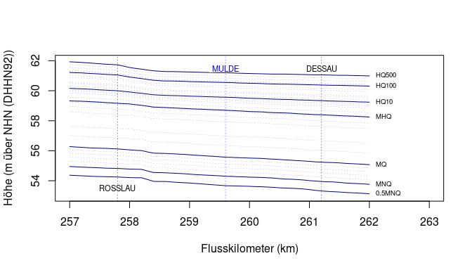

**Abb. 2**: [FLYS3](https://www.bafg.de/DE/5_Informiert/1_Portale_Dienste/FLYS/flys_node.html)-Wasserspiegellagen an der Elbe bei Rosslau und Dessau.

An Beispieldaten eines ausgesuchten Tages, dem 21.12.2016, umgeben drei stationäre [FLYS3](https://www.bafg.de/DE/5_Informiert/1_Portale_Dienste/FLYS/flys_node.html)-Wasserspiegellagen die tagesgemittelten Pegelmesswerte von Rosslau und Dessau und lassen erste visuelle Abschätzungen zu:

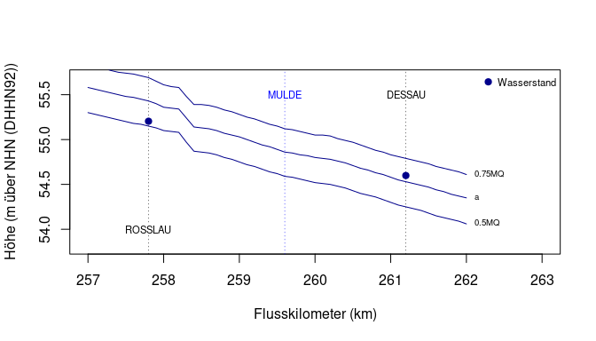

**Abb. 3**: Ausgewählte stationäre [FLYS3](https://www.bafg.de/DE/5_Informiert/1_Portale_Dienste/FLYS/flys_node.html)-Wasserspiegellagen (**0.5MQ**, **a** und **0.75MQ**) und Wasserstände vom 21.12.2016 an der Elbe bei Rosslau und Dessau.

Für die Berechnung eines Wasserstandes entlang der Gewässerachse eines Flusses mit Bezug zu einem Wasserstand an einem Pegel sind in der Weboberfläche von [FLYS3](https://www.bafg.de/DE/5_Informiert/1_Portale_Dienste/FLYS/flys_node.html) mehrere Arbeitsschritte vorzunehmen. Am Beispiel der Elbe zwischen Rosslau und Dessau für den Tag des 21.12.2016 sind dies:

1. Auswahl des Berechungsmoduls **W-INFO**
2. Auswahl des Gewässers **Elbe**
3. Auswahl der Berechnungsart **Wasserstand/Wasserspiegellage**
4. Festlegung der Berechnungsstrecke von Kilometer **257** bis **262** mit Werten alle **100** m
5. Auswahl des Bezugspegels **Wittenberg**
6. Eingabe des Bezugswasserstandes von **174** cm am Bezugspegel (Tagesmittelwert des 21.12.2016)

Diese Eingaben der genannten Daten liefern folgendes Ergebnis:

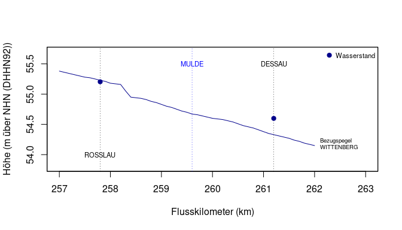

**Abb. 4**: [FLYS3](https://www.bafg.de/DE/5_Informiert/1_Portale_Dienste/FLYS/flys_node.html)-Wasserspiegellage an der Elbe bei Rosslau und Dessau bei einem Wasserstand von 174 cm am Pegel Wittenberg (Tagesmittelwert des 21.12.2016).

### Probleme durch die Auswahl des Bezugspegels

Am Pegel Rosslau ist die Abweichung zwischen gemessenem Wasserstand( 137 cm $\widehat{=}$ 55.2 m über NHN) und mittels [FLYS3](https://www.bafg.de/DE/5_Informiert/1_Portale_Dienste/FLYS/flys_node.html) berechnetem Wasserstand ( 140 cm $\widehat{=}$ 55.23 m über NHN) gering und beträgt nur -3 cm. Am Pegel Dessau, unterhalb der Mündung der Mulde, beträgt die Abweichung zwischen gemessenem Wasserstand ( 165 cm $\widehat{=}$ 54.6 m über NHN)) und mittels [FLYS3](https://www.bafg.de/DE/5_Informiert/1_Portale_Dienste/FLYS/flys_node.html) berechnetem Wasserstand ( 138 cm $\widehat{=}$ 54.33 m über NHN) aber bereits 27 cm.

Wendet man nun den [FLYS3](https://www.bafg.de/DE/5_Informiert/1_Portale_Dienste/FLYS/flys_node.html)-Algorithmus zur Interpolation der stationären Wasserspiegellagen mit den relevanten Bezugspegeln Rosslau und Dessau an und fügt diese der Abbildung hinzu, so ergibt sich folgendes Bild:

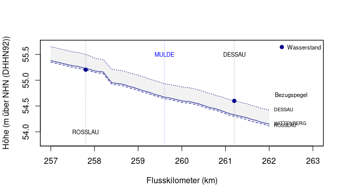

**Abb. 5**: [FLYS3](https://www.bafg.de/DE/5_Informiert/1_Portale_Dienste/FLYS/flys_node.html)-Wasserspiegellagen an der Elbe bei Rosslau und Dessau berechnet mittels der Bezugspegel Wittenberg, Rosslau und Dessau.

Ganz offensichtlich hat die Wahl des Bezugspegels einen maßgeblichen Einfluss auf die Lage der resultierenden Wasserspiegellagen und die Differenzen zwischen der höchsten und der niedrigsten der drei Wasserspiegellagen betragen 27 bis 31 cm.

Bedingt durch die Stationarität der [FLYS3](https://www.bafg.de/DE/5_Informiert/1_Portale_Dienste/FLYS/flys_node.html) zu Grunde liegenden SOBEK-Modelle, ist [FLYS3](https://www.bafg.de/DE/5_Informiert/1_Portale_Dienste/FLYS/flys_node.html) gut geeignet zeitlich gemittelte, langfristige Daten zu verarbeiten. Bei der Aufstellung der 30 stationären Abflussmodelle wurden Zuflüsse signifikanter Nebengewässer ebenso mit stationären, langfristig gemittelten Abflüssen als Randbedingungen integriert. In Situationen in denen Nebengewässer mit signifikanten Abflussvolumina jedoch stark vom Abflusszustand des Hauptgewässers abweichen, kommt die Wasserspiegellagenberechnung mittels [FLYS3](https://www.bafg.de/DE/5_Informiert/1_Portale_Dienste/FLYS/flys_node.html), die nur von einem Bezugspegel abhängt, an ihre Grenzen. Das wiederum führt zu starken Abweichungen im Bereich mehrerer Dezimeter zwischen berechneten Wasserspiegellagen und gemessenen Wasserständen.

Im verwendeten Beispiel liegt der Abfluss der Elbe am Pegel Rosslau knapp über **0.5MQ** (~200 m<sup>3</sup>/sec). Der Pegel Dessau-Brücke weist die Mulde einen relativ hohen Abfluss nahe eines **MQ** auf (~75 m<sup>3</sup>/sec), was unterhalb der Mündung dazu führt, dass die stationäre Wasserspiegellage **a** (~272 m<sup>3</sup>/sec) der Elbe überschritten wird. Der Wasserstand in Dessau ist somit ca. 30 cm höher, als die Wasserstandssituation in Rosslau erwarten ließ. Um derartige Effekte durch Instationaritäten aufzufangen und kontinuierliche Wasserspiegellagen berechnen zu können, sind also andere Berechnungsmethoden notwendig, welche im Folgenden präsentiert werden.

# Die Lösung

Das R-Paket **hyd1d** wurde entwickelt, um die Instationaritäten, die bei der Verwendung von [FLYS3](https://www.bafg.de/DE/5_Informiert/1_Portale_Dienste/FLYS/flys_node.html) Probleme bereiten, zu berücksichtigen und durchgehende, stetige Wasserspiegellagen für lange Gewässerabschnitte zu berechnen. Dafür werden Pegeldaten, die über [PEGELONLINE](https://pegelonline.wsv.de/gast/start) oder die [WISKI7](https://www.bafg.de/DE/3_Beraet/2_Exp_quantitaet/Hydrologie_M1/hydrologie_node.html#vt-sprg-3)-Datenbank zur Verfügung stehen oder gestellt werden können, mit den stationären Wasserspiegellagen von [FLYS3](https://www.bafg.de/DE/5_Informiert/1_Portale_Dienste/FLYS/flys_node.html) verrechnet.

## Grundlagen

Die grundlegenden Daten, die für die Berechnung von Wasserspiegellagen verwendet werden, wurden in der Problembeschreibung bereits genannt und verwendet. Dabei handelt es sich einerseits um Pegeldaten, andererseits um die Wasserspiegellagen von [FLYS3](https://www.bafg.de/DE/5_Informiert/1_Portale_Dienste/FLYS/flys_node.html).

### Pegeldaten

In den Funktionen des Paketes **hyd1d** werden zwei unterschiedliche Datenbestände von Pegeldaten verwendet und über Stammdaten verknüpft.

#### PEGELONLINE

Das Portal [PEGELONLINE](https://pegelonline.wsv.de/gast/start) ermöglicht einen Zugriff auf **unvalidierte** Pegelmesswerte aller Pegel, die von der Wasserstraßen- und Schifffahrstverwaltung betrieben werden. Diese Daten sind jedoch nur 30 Tage rückwirkend vorhanden und werden dannach vom Server gelöscht.

Der Zugriff auf diese Daten innerhalb von **hyd1d** erfolgt online über die PEGELONLINE REST-Schnittstelle, die allen Entwicklern offen steht und gut dokumentiert ist:

https://www.pegelonline.wsv.de/webservice/dokuRestapi

Entsprechend kodierte Abfragen auf die PEGELONLINE REST-Schnittstelle werden mit Objekten in JSON-Notation beantwortet, die paketintern weiter verarbeitet werden.

#### WISKI7

[WISKI7](https://www.bafg.de/DE/3_Beraet/2_Exp_quantitaet/Hydrologie_M1/hydrologie_node.html#vt-sprg-3), die gewässerkundliche Datenbank der WSV, wird durch die BfG betrieben und gepflegt. Diese Datenbank enthält **validierte**, teilweise auch historische Wasserstands- und Abflussdaten für mehrere hundert Pegel der WSV und auch der Bundesländer. Allerdings sind diese Datenbestände bisher nicht online verfügbar. Daher wird innerhalb des Pakets **hyd1d** ein Auszug aus der [WISKI7](https://www.bafg.de/DE/3_Beraet/2_Exp_quantitaet/Hydrologie_M1/hydrologie_node.html#vt-sprg-3)-Datenbank mitgeliefert.

Konkret handelt es sich dabei um tagesgemittelte Wasserstandswerte für die Pegel entlang des Rheins und der deutschen Binnenelbe seit dem 01.01.1960. Diese Pegeldaten sind innerhalb des Paketes als `data.frame`-Objekt `df.gauging_data` eingebettet und werden paket-intern regelmäßig automatisiert aktualisiert (`updateGaugingData()`).

#### Stammdaten

Um die Daten von [PEGELONLINE](https://pegelonline.wsv.de/gast/start) und aus der [WISKI7](https://www.bafg.de/DE/3_Beraet/2_Exp_quantitaet/Hydrologie_M1/hydrologie_node.html#vt-sprg-3)-Datenbank nebeneinander nutzen und verknüpfen zu können, sind Stammdaten notwendig. Innerhalb des Pakets **hyd1d** ist ein eigener Stammdatensatz vorhanden (`df.gauging_station_data`), der zentral gepflegt und aktualisiert wird.

### FLYS3 Wasserspiegellagen

Auch die stationären Wasserspiegellagen für Elbe und Rhein aus [FLYS3](https://www.bafg.de/DE/5_Informiert/1_Portale_Dienste/FLYS/flys_node.html) sind in das Paket **hyd1d** integriert. Der paket-interne Datensatz `df.flys` beinhaltet die 30 stationären Wasserspiegellagen für den Rhein (HKV Hydrokontor, 2014) und die Elbe (Busch & Hammer, 2009). Die räumlichen Auflösung der Daten beträgt im Normalfall 200 m, was Wasserspiegellageninformationen an jedem gerade Hektometer entspricht. Alle Wasserspiegellageninformationen dazwischen müssen linear interpoliert werden (`waterLevelFlys3InterpolateX()`).

## Methodik

Während die bisher üblichen Verfahren der Abschätzung oder Berechnung von Wasserspiegellagen (PEGELONLINE und FLYS3) nur einen Bezugspegel haben, verwendet **hyd1d** die verfügbaren Pegeldaten aller Pegel auf der zu berechnenden Strecke und die nächsten oberhalb und unterhalb gelegenen. An den Pegeln selbst entspricht der berechnete Wasserstand den Pegelmesswerten. Zwischen den Pegeln erfolgt eine entfernungsabhängige Interpolation anhand der Wasserspiegellagen von [FLYS3](https://www.bafg.de/DE/5_Informiert/1_Portale_Dienste/FLYS/flys_node.html).

Insgesamt gliedert sich die Berechnung in fünf Schritte, die im weiteren Verlauf näher erläutert werden:

1. Bestimmung der relevanten Pegel für den Berechnungsort, bzw. die Berechnungsstrecke
2. Berechnung der Wasserspiegellagen an den relevanten Pegeln für einen gewählten Zeitpunkt
3. Aufteilung der Berechnungsstrecke in Abschnitte, die von jeweils zwei Pegeln eingerahmt werden
4. Abschnittsweise Bestimmung, welche [FLYS3](https://www.bafg.de/DE/5_Informiert/1_Portale_Dienste/FLYS/flys_node.html)-Wasserspiegellagen die Wasserspiegellagen an den beiden Pegeln einrahmen
5. Abschnittsweise, entfernungsabhängige Interpolation zwischen den einrahmenden [FLYS3](https://www.bafg.de/DE/5_Informiert/1_Portale_Dienste/FLYS/flys_node.html)-Wasserspiegellagen

### Auswahl streckenbezogener Bezugspegel

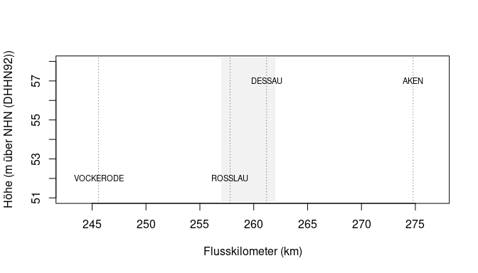

**Abb. 6**: Relevante Bezugspegel für die Berechnungsstrecke von Kilometer 257 bis 262 an der Elbe bei Rosslau und Dessau.

### Berechnung der Wasserspiegellagen an den Bezugspegeln

Im folgenden Schritt werden die Pegeldaten für einen gewählten Zeitpunkt ermittelt, was in diesem Beispiel der 21.12.2016 ist. Dafür werden die Wasserstandswerte (cm) durch 100 dividiert und zu dem jeweiligen Pegelnullpunkt (PNP in m über Normalhöhennull (NHN)) addiert.

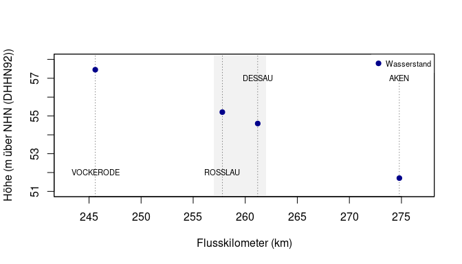

**Abb. 7**: Wasserstände an den relevanten Bezugspegeln für die Berechnungsstrecke von Kilometer 257 bis 262 an der Elbe bei Rosslau und Dessau.

### Bestimmung der einrahmenden FLYS3-Wasserspiegellagen

Die weiteren Berechnungen erfolgen abschnittsweise, wobei die jeweiligen Berechnungsabschnitte jeweils von zwei benachbarten Pegeln eingerahmt werden.

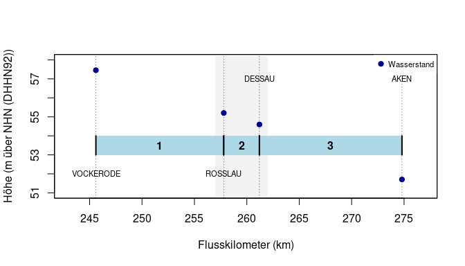

**Abb. 8**: Berechnungsabschnitte für die Berechnungsstrecke von Kilometer 257 bis 262 an der Elbe bei Rosslau und Dessau.

Das bedeutet, dass die Beispielstrecke in drei Berechnungsabschnitte aufgeteilt wird:

1. VOCKERODE - ROSSLAU
2. ROSSLAU - DESSAU
3. DESSAU - AKEN

Anhand des zweiten Abschnitts von Rosslau bis Dessau erklärt sich dann auch die Selektion der einrahmenden [FLYS3](https://www.bafg.de/DE/5_Informiert/1_Portale_Dienste/FLYS/flys_node.html)-Wasserspiegellagen:

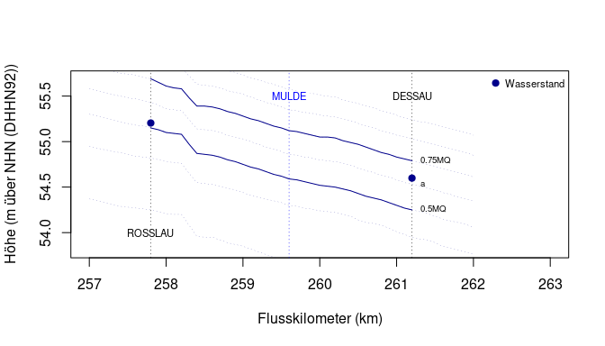

**Abb. 9**: Ausgewählte stationäre [FLYS3](https://www.bafg.de/DE/5_Informiert/1_Portale_Dienste/FLYS/flys_node.html)-Wasserspiegellagen (**0.5MQ** und **0.75MQ**) und Wasserstände vom 21.12.2016 an der Elbe bei Rosslau und Dessau.

Die Wasserspiegellage **0.5MQ** ist die höchste [FLYS3](https://www.bafg.de/DE/5_Informiert/1_Portale_Dienste/FLYS/flys_node.html)-Wasserspiegellage, die niedriger ist als die Wasserstände an den beiden Pegeln Rosslau und Dessau. Die Wasserspiegellage **0.75MQ** ist die niedrigste [FLYS3](https://www.bafg.de/DE/5_Informiert/1_Portale_Dienste/FLYS/flys_node.html)-Wasserspiegellage, die höher ist als die Wasserstände an den Pegeln. Die Wasserspiegellage **a**, die zwischen den Wasserspiegellagen **0.5MQ** und **0.75MQ** liegt, wird am Pegel Rosslau unterschritten, am Pegel Dessau aber überschritten und ist damit für den folgenden Schritt der Interpolation ungeeignet.

### Interpolation zwischen den einrahmenden FLYS3-Wasserspiegellagen

In einem vorbereitenden Schritt wird nun die relative Lage der gemessenen Wasserstände an den Pegeln zu den einrahmenden [FLYS3](https://www.bafg.de/DE/5_Informiert/1_Portale_Dienste/FLYS/flys_node.html)-Wasserspiegellagen **0.5MQ** und **0.75MQ** bestimmt. Die niedrigere Wasserspiegellage **0.5MQ** erhält dabei das Gewicht 0, die höhere Wasserspiegellage **0.75MQ** das Gewicht 1. Die Wasserstände an den Pegel liegen im Standardfall zwischen 0 und 1 (0 - 1 x der Differenz von **0.75MQ** - **0.5MQ**). Nur in Situationen, in denen der Wasserstand an einem Pegel höher liegt als die höchste [FLYS3](https://www.bafg.de/DE/5_Informiert/1_Portale_Dienste/FLYS/flys_node.html)-Wasserspiegellage HQ500, wird das realtive Gewicht größer als 1. In Situationen, in denen die niedrigste [FLYS3](https://www.bafg.de/DE/5_Informiert/1_Portale_Dienste/FLYS/flys_node.html)-Wasserspiegellage 0.5MNQ an einem Pegel unterschritten wird, kann das relative Gewicht auch negativ werden.

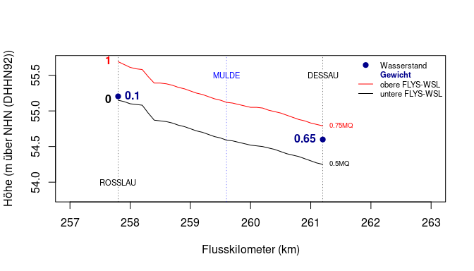

**Abb. 10**: Ausgewählte stationäre [FLYS3](https://www.bafg.de/DE/5_Informiert/1_Portale_Dienste/FLYS/flys_node.html)-Wasserspiegellagen (**0.5MQ** und **0.75MQ**) und Wasserstände vom 21.12.2016 an der Elbe bei Rosslau und Dessau und deren relative Lage zwischen den [FLYS3](https://www.bafg.de/DE/5_Informiert/1_Portale_Dienste/FLYS/flys_node.html)-Wasserspiegellagen.

Diese relativen Gewichte an den Pegeln werden über die Strecke zwischen den Pegeln linear interpoliert.

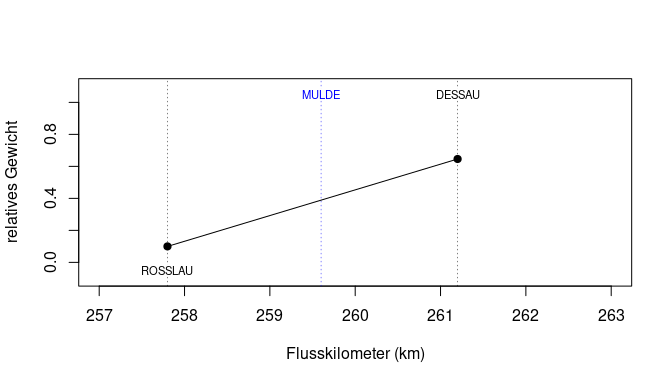

**Abb. 11**: Relatives Gewicht für die Interpolation der Wasserstände vom 21.12.2016 an der Elbe bei Rosslau und Dessau zwischen den [FLYS3](https://www.bafg.de/DE/5_Informiert/1_Portale_Dienste/FLYS/flys_node.html)-Wasserspiegellagen **0.5MQ** und **0.75MQ**.

Kombiniert man nun die lineare Interpolation des Gewichts zwischen den einrahmenden [FLYS3](https://www.bafg.de/DE/5_Informiert/1_Portale_Dienste/FLYS/flys_node.html)-Wasserspiegellagen **0.5MQ** und **0.75MQ** mit den Wasserständen über folgende mathematische Beziehung:

$WSL = WSL_{0.5MQ} + Gewicht * (WSL_{0.75MQ} - WSL_{0.5MQ})$

Dann erhält man für den 2. Abschnitt folgendes Produkt:

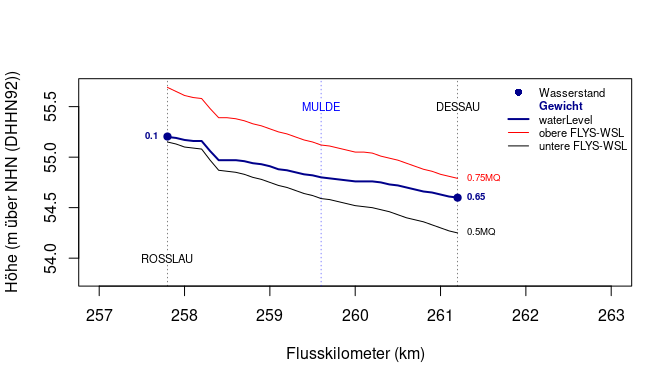

**Abb. 12**: Interpolierte Wasserspiegellage, ausgewählte stationäre [FLYS3](https://www.bafg.de/DE/5_Informiert/1_Portale_Dienste/FLYS/flys_node.html)-Wasserspiegellagen (**0.5MQ** und **0.75MQ**) und Wasserstände vom 21.12.2016 an der Elbe bei Rosslau und Dessau.

Nach Kombination der Daten aller drei Berechungsabschnitte erhält man folgendes, finales Produkt:

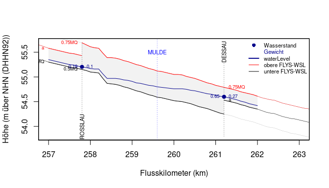

**Abb. 13**: Interpolierte Wasserspiegellage, berechnungsrelevante stationäre [FLYS3](https://www.bafg.de/DE/5_Informiert/1_Portale_Dienste/FLYS/flys_node.html)-Wasserspiegellagen (**0.5MQ**, **a** und **0.75MQ**) und Wasserstände vom 21.12.2016 an der Elbe bei Rosslau und Dessau.

# Anwendung

## Installation und Laden des Paketes

Das Paket **hyd1d** ist auf CRAN verfügbar. Um es zu installieren reicht ein:

```r
install.packages("hyd1d")
```

Um die aktuelle Entwicklungsversion von Github zu installieren, müssen folgende Befehle ausgeführt werden:

```r
install.packages("devtools")
library(devtools)
devtools::install_github("bafg-bund/hyd1d")
```

Dannach kann das Paket **hyd1d** wie jedes andere installierte R-Paket über folgenden Befehl geladen werden:

```r
library(hyd1d)
```

## S4-Klasse WaterLevelDataFrame

Grundlage der Wasserspiegellagenberechungen mittels **hyd1d** ist die S4-Klasse `WaterLevelDataFrame`. Um Wasserspiegellagenberechnungen mit einer der `waterLevel…()`-Funktionen durchführen zu können, benötigt man zunächst einen initialisierten `WaterLevelDataFrame`, den man mit der gleichnamigen `WaterLevelDataFrame()`-Funktion anlegen kann:

```r
wldf <- WaterLevelDataFrame(river   = "Elbe",
                            time    = as.POSIXct("2016-12-21"),
                            station = seq(257, 262, 0.1))
```

Mindestinformationen, die für das Anlegen eines `WaterLevelDataFrame` nötig sind, sind die Argumente `river`, `time` und eines der zwei möglichen Stationierungsargumente (`station` oder `station_int`). Mit diesen Informationen wird ein Object der Klasse `WaterLevelDataFrame` angelegt, welches folgende Struktur aufweist:

```r
str(wldf)
```

```
#> 'data.frame':    51 obs. of  3 variables:
#> Formal class 'WaterLevelDataFrame' [package "hyd1d"] with 9 slots
#>   ..@ .Data                   :List of 3
#>   .. ..$ : num  257 257 257 257 257 ...
#>   .. ..$ : int  257000 257100 257200 257300 257400 257500 257600 257700 257800 257900 ...
#>   .. ..$ : num  NA NA NA NA NA NA NA NA NA NA ...
#>   ..@ river                   : chr "Elbe"
#>   ..@ time                    : POSIXct, format: "2016-12-21"
#>   ..@ gauging_stations        :'data.frame': 0 obs. of  27 variables:
#>   .. ..$ id                : int
#>   .. ..$ gauging_station   : chr
#>   .. ..$ uuid              : chr
#>   .. ..$ km                : num
#>   .. ..$ km_qps            : num
#>   .. ..$ river             : chr
#>   .. ..$ longitude         : num
#>   .. ..$ latitude          : num
#>   .. ..$ mw                : num
#>   .. ..$ mw_timespan       : chr
#>   .. ..$ pnp               : num
#>   .. ..$ w                 : num
#>   .. ..$ wl                : num
#>   .. ..$ n_wls_below_w_do  : int
#>   .. ..$ n_wls_above_w_do  : int
#>   .. ..$ n_wls_below_w_up  : int
#>   .. ..$ n_wls_above_w_up  : int
#>   .. ..$ name_wl_below_w_do: chr
#>   .. ..$ name_wl_above_w_do: chr
#>   .. ..$ name_wl_below_w_up: chr
#>   .. ..$ name_wl_above_w_up: chr
#>   .. ..$ w_wl_below_w_do   : num
#>   .. ..$ w_wl_above_w_do   : num
#>   .. ..$ w_wl_below_w_up   : num
#>   .. ..$ w_wl_above_w_up   : num
#>   .. ..$ weight_up         : num
#>   .. ..$ weight_do         : num
#>   ..@ gauging_stations_missing: chr NA
#>   ..@ comment                 : chr "Initialised by WaterLevelDataFrame()."
#>   ..@ names                   : chr  "station" "station_int" "w"
#>   ..@ row.names               : int  1 2 3 4 5 6 7 8 9 10 ...
#>   ..@ .S3Class                : chr "data.frame"
```

```r
summary(wldf)
```

```
#> $slots
#>
#> river                                                     Elbe
#> time                                                2016-12-21
#> gauging_stations                                          None
#> gauging_stations_missing                                  None
#> comment                  Initialised by WaterLevelDataFrame().
#>
#> $data
#>     station       station_int           w
#>  Min.   :257.0   Min.   :257000   Min.   : NA
#>  1st Qu.:258.2   1st Qu.:258250   1st Qu.: NA
#>  Median :259.5   Median :259500   Median : NA
#>  Mean   :259.5   Mean   :259500   Mean   :NaN
#>  3rd Qu.:260.8   3rd Qu.:260750   3rd Qu.: NA
#>  Max.   :262.0   Max.   :262000   Max.   : NA
#>                                   NA's   :51
```

Die eigentliche Wasserspiegellageninformation ist im S4-Slot `.Data` enthalten, bei der es sich um einen `data.frame` handelt, der mindestens die Spalten `station`, `station_int` und `w` beinhaltet. Die Spalten `station` und `station_int` enthalten eine Stationierungsinformation, die der offiziellen Flusskilometrierung der Wasserstraßen- und Schifffahrtsverwaltung entspricht. Die Doppelung der Stationierungsinformation ist vorgesehen, um über die Spalte `station_int`, welche ein `integer`-Typ hat, zuverlässige Datenbank-Joins zu Geodaten machen zu können. Die Spalte `w` beinhaltet den Wasserstand im Höhenbezugssystem DHHN92, ist nach der Initialisierung zunächst leer (`NA`) und wird durch Anwendung der `waterLevel…()`-Funktionen erst gefüllt.

Für die Verwendung der `waterLevel…()`-Funktionen sind die Informationen der S4-Slots `river` und gegebenenfalls auch `time` essentiell. Erst sie ermöglichen eine eindeutige Lokalisation der Stationierung entlang der Elbe und des Rheins und die Festlegung des Berechungszeitpunktes. Die weiteren Slots eines Objektes der Klasse `WaterLevelDataFrame` werden erst bei einer Wasserspiegellagenberechnung gefüllt und enthalten Teilergebnisse, die zum Beispiel zur Visualisierung notwendig sind (`gauging_station`) oder informativen Charakter haben (`gauging_stations_missing`, `comment`).

## Berechnung von Wasserspiegellagen

### waterLevel

Die zuvor detailliert beschriebene Interpolation von [FLYS3](https://www.bafg.de/DE/5_Informiert/1_Portale_Dienste/FLYS/flys_node.html)-Wasserspiegellagen anhand von Pegeldaten ist in der Funktion `waterLevel()` implementiert. Diese Funktion nutzt für die Interpolation die Paket-internen Pegeldaten aus dem Datensatz `df.gauging_data`, welcher tages-gemittelte Pegeldaten seit dem 01.01.1960 enthält. Daher sind Berechungen für den Zeitraum vom 01.01.1960 bis gestern möglich.

Nach der Initialisierung eines Objektes der Klasse `WaterLevelDataFrame` ist die Verwendung der Funktion denkbar einfach:

```r
wldf <- waterLevel(wldf)
summary(wldf)
```

```
#> $slots
#>
#> river                                                Elbe
#> time                                           2016-12-21
#> gauging_stations         VOCKERODE, ROSSLAU, DESSAU, AKEN
#> gauging_stations_missing                             None
#> comment                         Computed by waterLevel().
#>
#> $data
#>     station       station_int           w
#>  Min.   :257.0   Min.   :257000   Min.   :54.42
#>  1st Qu.:258.2   1st Qu.:258250   1st Qu.:54.67
#>  Median :259.5   Median :259500   Median :54.82
#>  Mean   :259.5   Mean   :259500   Mean   :54.87
#>  3rd Qu.:260.8   3rd Qu.:260750   3rd Qu.:55.11
#>  Max.   :262.0   Max.   :262000   Max.   :55.35
```

Soll das Berechnungsergebnis auch noch mittels `plotShiny()` visualisiert werden, so sollte zusätzlich noch das Argument `shiny = TRUE` genutzt werden:

```r
wldf <- waterLevel(wldf, shiny = TRUE)
summary(wldf)
```

```
#> $slots
#>
#> river                                                Elbe
#> time                                           2016-12-21
#> gauging_stations         VOCKERODE, ROSSLAU, DESSAU, AKEN
#> gauging_stations_missing                             None
#> comment                         Computed by waterLevel().
#>
#> $data
#>     station       station_int           w            section
#>  Min.   :257.0   Min.   :257000   Min.   :54.42   Min.   :1.00
#>  1st Qu.:258.2   1st Qu.:258250   1st Qu.:54.67   1st Qu.:2.00
#>  Median :259.5   Median :259500   Median :54.82   Median :2.00
#>  Mean   :259.5   Mean   :259500   Mean   :54.87   Mean   :2.02
#>  3rd Qu.:260.8   3rd Qu.:260750   3rd Qu.:55.11   3rd Qu.:2.00
#>  Max.   :262.0   Max.   :262000   Max.   :55.35   Max.   :3.00
#>     weight_x           weight_y
#>  Min.   :0.008197   Min.   :0.1000
#>  1st Qu.:0.161765   1st Qu.:0.1911
#>  Median :0.529412   Median :0.2640
#>  Mean   :0.520204   Mean   :0.3192
#>  3rd Qu.:0.897059   3rd Qu.:0.4294
#>  Max.   :1.000000   Max.   :0.6302
```

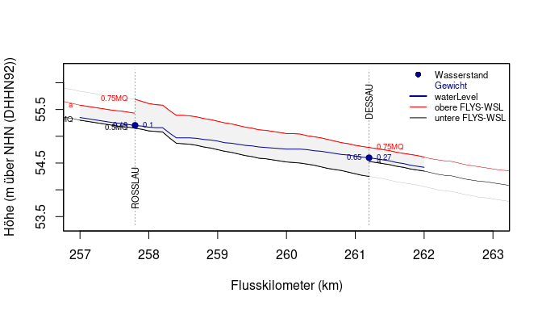

**Abb. 14**: Interpolierte Wasserspiegellage, berechnungsrelevante stationäre [FLYS3](https://www.bafg.de/DE/5_Informiert/1_Portale_Dienste/FLYS/flys_node.html)-Wasserspiegellagen (**0.5MQ**, **a** und **0.75MQ**) und Wasserstände vom 21.12.2016 an der Elbe bei Rosslau und Dessau.

```r
xlim_min <- 257
xlim_max <- 263
plotShiny(wldf, TRUE, TRUE, TRUE, xlim = c(xlim_min, xlim_max))
legend("topright",
       col = c("darkblue", "darkblue", "darkblue", "red", "black"),
       pch = c(21, NA, NA, NA, NA),
       pt.bg = c("darkblue", NA, NA, NA, NA),
       pt.cex = c(1, NA, NA, NA, NA),
       lty = c(0, 0, 1, 1, 1),
       lwd = c(0, 0, 2, 1, 1),
       legend = c("Wasserstand", "Gewicht", "waterLevel", "obere FLYS-WSL",
                  "untere FLYS-WSL"),
       text.col = c(1, "darkblue", 1, 1, 1),
       cex = 0.7, bty = "n")
```

Dadurch werden zusätzlich zu den Spalten `station`, `station_int` und `w` des `.Data`-Slots die Spalten `section`, `weight_x` und `weight_y` angelegt, die für das Visualisieren notwendig sind.

### waterLevelPegelonline

Die Funktion `waterLevelPegelonline()` funktioniert equivalent zur Funktion `waterLevel()`, greift für die Berechung aber auf eine andere Datenquelle für die Pegeldaten zurück, nämlich https://pegelonline.wsv.de/gast/start. Auf Grund dieser externen Datenquelle sind Berechnungen auch nur 30 Tage rückwirkend möglich, aber mit einer hohen zeitlichen Auflösung.

```r
# one hour ago
time <- as.POSIXct(Sys.time() - 3600)

# initialize a WaterLevelDataFrame
wldf <- WaterLevelDataFrame(river   = "Elbe",
                            time    = time,
                            station = seq(257, 262, 0.1))

# compute w
wldf <- waterLevelPegelonline(wldf, shiny = TRUE)
summary(wldf)
```

```
#> $slots
#>
#> river                                                    Elbe
#> time                               2025-02-26 08:07:56.430448
#> gauging_stations             VOCKERODE, ROSSLAU, DESSAU, AKEN
#> gauging_stations_missing                                 None
#> comment                  Computed by waterLevelPegelonline().
#>
#> $data
#>     station       station_int           w            section
#>  Min.   :257.0   Min.   :257000   Min.   :54.40   Min.   :1.00
#>  1st Qu.:258.2   1st Qu.:258250   1st Qu.:54.66   1st Qu.:2.00
#>  Median :259.5   Median :259500   Median :54.82   Median :2.00
#>  Mean   :259.5   Mean   :259500   Mean   :54.87   Mean   :2.02
#>  3rd Qu.:260.8   3rd Qu.:260750   3rd Qu.:55.13   3rd Qu.:2.00
#>  Max.   :262.0   Max.   :262000   Max.   :55.39   Max.   :3.00
#>     weight_x           weight_y
#>  Min.   :0.008197   Min.   :0.1556
#>  1st Qu.:0.161765   1st Qu.:0.2023
#>  Median :0.529412   Median :0.3079
#>  Mean   :0.520204   Mean   :0.3310
#>  3rd Qu.:0.897059   3rd Qu.:0.4291
#>  Max.   :1.000000   Max.   :0.5959
```

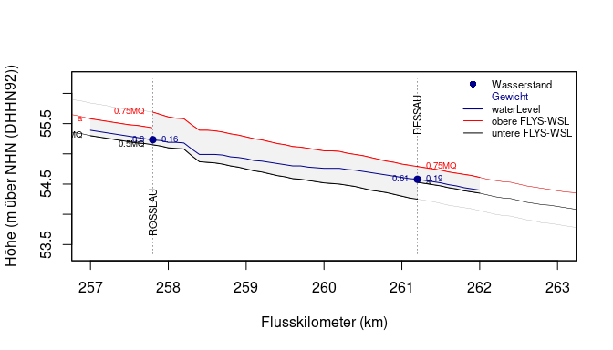

**Abb. 15**: Interpolierte Wasserspiegellage, berechnungsrelevante stationäre [FLYS3](https://www.bafg.de/DE/5_Informiert/1_Portale_Dienste/FLYS/flys_node.html)-Wasserspiegellagen und Wasserstände vom 26.02.2025 08:07 Uhr an der Elbe bei Rosslau und Dessau.

```r
# and plot the results
plotShiny(wldf, TRUE, TRUE, TRUE, xlim = c(xlim_min, xlim_max))
legend("topright",
       col = c("darkblue", "darkblue", "darkblue", "red", "black"),
       pch = c(21, NA, NA, NA, NA),
       pt.bg = c("darkblue", NA, NA, NA, NA),
       pt.cex = c(1, NA, NA, NA, NA),
       lty = c(0, 0, 1, 1, 1),
       lwd = c(0, 0, 2, 1, 1),
       legend = c("Wasserstand", "Gewicht", "waterLevel", "obere FLYS-WSL",
                  "untere FLYS-WSL"),
       text.col = c(1, "darkblue", 1, 1, 1),
       cex = 0.7, bty = "n")
```

### waterLevelFlood1 & waterLevelFlood2

Um die neu entwickelten Funktionen `waterLevel()` und `waterLevelPegelonline()` mit den existierenden Berechnungsmethoden vergleichen zu können, wurde auch die Funktionen `waterLevelFlood1()` und `waterLevelFlood2()` implementiert. Diese Funktionen berechnen Wasserspiegellagen analog zur Flut1- und Flut2-Methoden der Modellierungsumgebung [INFORM](https://www.bafg.de/DE/3_Beraet/4_Exp_oekologie/Flussauenmodell_INFORM_U3/flussauenmodell_inform_node.html) (Rosenzweig, Giebel, & Schleuter, 2011). Dazu wird mittels der Flut1-Methode die Referenzwasserspiegellage **MQ** vertikal so verschoben, dass sie den Wasserstandswert am ausgewählten Bezugspegel schneidet, bei der Flut2-Methode werden Wasserspiegellagen durch lineare Interpolation umliegender Pegeldaten berechnet.

```r
wldf <- WaterLevelDataFrame(river   = "Elbe",
                            time    = as.POSIXct("2016-12-21"),
                            station = seq(257, 262, 0.1))

wldf1 <- waterLevelFlood1(wldf, "ROSSLAU", shiny = TRUE)
summary(wldf1)
```

```
#> $slots
#>
#> river                                                                                  Elbe
#> time                                                                             2016-12-21
#> gauging_stations                                                                    ROSSLAU
#> gauging_stations_missing                                                               None
#> comment                  Computed by waterLevelFlood1(): gauging_station = ROSSLAU, w = 137
#>
#> $data
#>     station       station_int           w            section     weight_x
#>  Min.   :257.0   Min.   :257000   Min.   :54.15   Min.   :1   Min.   :1
#>  1st Qu.:258.2   1st Qu.:258250   1st Qu.:54.44   1st Qu.:1   1st Qu.:1
#>  Median :259.5   Median :259500   Median :54.68   Median :1   Median :1
#>  Mean   :259.5   Mean   :259500   Mean   :54.73   Mean   :1   Mean   :1
#>  3rd Qu.:260.8   3rd Qu.:260750   3rd Qu.:55.05   3rd Qu.:1   3rd Qu.:1
#>  Max.   :262.0   Max.   :262000   Max.   :55.36   Max.   :1   Max.   :1
#>     weight_y
#>  Min.   :-0.92
#>  1st Qu.:-0.92
#>  Median :-0.92
#>  Mean   :-0.92
#>  3rd Qu.:-0.92
#>  Max.   :-0.92
```

```r
wldf2 <- waterLevelFlood1(wldf, "DESSAU", shiny = TRUE)
summary(wldf2)
```

```
#> $slots
#>
#> river                                                                                 Elbe
#> time                                                                            2016-12-21
#> gauging_stations                                                                    DESSAU
#> gauging_stations_missing                                                              None
#> comment                  Computed by waterLevelFlood1(): gauging_station = DESSAU, w = 165
#>
#> $data
#>     station       station_int           w            section     weight_x
#>  Min.   :257.0   Min.   :257000   Min.   :54.43   Min.   :1   Min.   :1
#>  1st Qu.:258.2   1st Qu.:258250   1st Qu.:54.72   1st Qu.:1   1st Qu.:1
#>  Median :259.5   Median :259500   Median :54.96   Median :1   Median :1
#>  Mean   :259.5   Mean   :259500   Mean   :55.01   Mean   :1   Mean   :1
#>  3rd Qu.:260.8   3rd Qu.:260750   3rd Qu.:55.33   3rd Qu.:1   3rd Qu.:1
#>  Max.   :262.0   Max.   :262000   Max.   :55.64   Max.   :1   Max.   :1
#>     weight_y
#>  Min.   :-0.64
#>  1st Qu.:-0.64
#>  Median :-0.64
#>  Mean   :-0.64
#>  3rd Qu.:-0.64
#>  Max.   :-0.64
```

```r
wldf3 <- waterLevelFlood2(wldf)
summary(wldf3)
```

```
#> $slots
#>
#> river                                                Elbe
#> time                                           2016-12-21
#> gauging_stations         VOCKERODE, ROSSLAU, DESSAU, AKEN
#> gauging_stations_missing                             None
#> comment                    Computed by waterLevelFlood2()
#>
#> $data
#>     station       station_int           w
#>  Min.   :257.0   Min.   :257000   Min.   :54.43
#>  1st Qu.:258.2   1st Qu.:258250   1st Qu.:54.68
#>  Median :259.5   Median :259500   Median :54.90
#>  Mean   :259.5   Mean   :259500   Mean   :54.90
#>  3rd Qu.:260.8   3rd Qu.:260750   3rd Qu.:55.12
#>  Max.   :262.0   Max.   :262000   Max.   :55.35
```

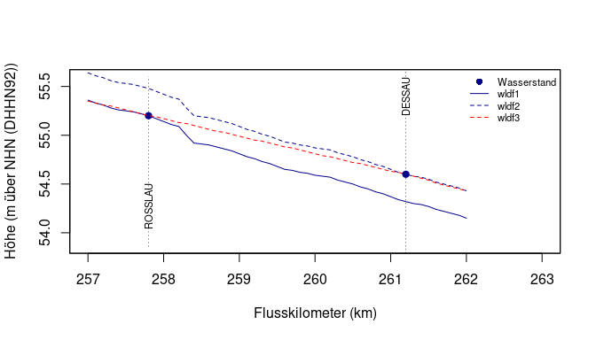

**Abb. 16**: Wasserspiegellagen nach Flut1 mit den Bezugspegeln Rosslau (wldf1) und Dessau (wldf2) und Flut2 (wldf3) für den 21.12.2016 an der Elbe bei Rosslau und Dessau.

### waterLevelFlys3InterpolateY

Um die neu entwickelten Funktionen `waterLevel()` und `waterLevelPegelonline()` mit den existierenden Berechnungsmethoden von [FLYS3](https://www.bafg.de/DE/5_Informiert/1_Portale_Dienste/FLYS/flys_node.html) vergleichen zu können, wurde auch die Funktion `waterLevelFlys3InterpolateY()` implementiert. Diese Funktion berechnet Wasserspiegellagen analog zu der Methode, wie sie im W-Info-Modul von [FLYS3](https://www.bafg.de/DE/5_Informiert/1_Portale_Dienste/FLYS/flys_node.html) implementiert ist. Dazu wird die relative Lage des Wasserstandes zu den zwei einrahmenden [FLYS3](https://www.bafg.de/DE/5_Informiert/1_Portale_Dienste/FLYS/flys_node.html)-Wasserspiegellagen an dem ausgewählten Bezugspegel bestimmt und dann für eine Interpolation zwischen diesen beiden Wasserspiegellagen verwendet.

```r
wldf <- waterLevelFlys3InterpolateY(wldf, "ROSSLAU", shiny = TRUE)
summary(wldf)
```

```
#> $slots
#>
#> river                                                                                             Elbe
#> time                                                                                        2016-12-21
#> gauging_stations                                                                               ROSSLAU
#> gauging_stations_missing                                                                          None
#> comment                  Computed by waterLevelFlys3InterpolateY(): gauging_station = ROSSLAU, w = 137
#>
#> $data
#>     station       station_int           w            section     weight_x
#>  Min.   :257.0   Min.   :257000   Min.   :54.11   Min.   :1   Min.   :1
#>  1st Qu.:258.2   1st Qu.:258250   1st Qu.:54.42   1st Qu.:1   1st Qu.:1
#>  Median :259.5   Median :259500   Median :54.67   Median :1   Median :1
#>  Mean   :259.5   Mean   :259500   Mean   :54.72   Mean   :1   Mean   :1
#>  3rd Qu.:260.8   3rd Qu.:260750   3rd Qu.:55.08   3rd Qu.:1   3rd Qu.:1
#>  Max.   :262.0   Max.   :262000   Max.   :55.35   Max.   :1   Max.   :1
#>     weight_y
#>  Min.   :0.1786
#>  1st Qu.:0.1786
#>  Median :0.1786
#>  Mean   :0.1786
#>  3rd Qu.:0.1786
#>  Max.   :0.1786
```

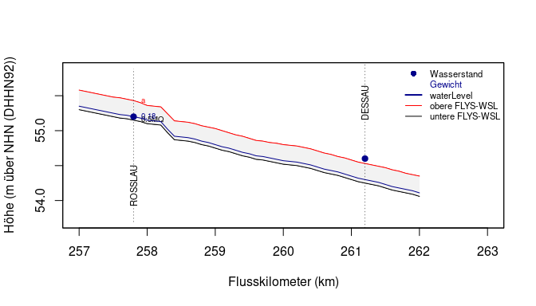

**Abb. 17**: Wasserspiegellage nach [FLYS3](https://www.bafg.de/DE/5_Informiert/1_Portale_Dienste/FLYS/flys_node.html) mit dem Bezugspegel Rosslau für den 21.12.2016 an der Elbe bei Rosslau und Dessau.

### waterLevelFlys3…

Alle weiteren `waterLevelFlys3...`-Funktionen (`waterLevelFlys3()`, `waterLevelFlys3Seq()` und `waterLevelFlys3InterpolateX()`) dienen ausschließlich der Aufbereitung und Abfrage von FLYS3-Wasserspiegellagen. Sie können verwendet werden, um die Wasserspiegellagen des Datensatzes `df.flys` zu extrahieren oder entlang der x-Achse zu linear zu interpolieren, was aber keine inhaltliche Veränderung der Daten nach sich zieht. Diese Funktionalitäten werden innerhalb **aller** zuvor beschriebenen `waterLevel…()`-Funktionen verwendet und hier nur der Vollständigkeit halber erwähnt.

# Produkte

Im Zusammenhang mit der Entwicklung des vorliegenden R-Paketes **hyd1d** wurden verschiedene Datenbestände aufbereitet, bzw. können nun mit Veröffentlichung der Werkzeuge besser genutzt werden. Im Folgenden findet sich Produkte, die den Zugriff auf die den Berechnungsverfahren zu Grunde liegenden Daten vereinfachen oder schon berechnete Ergebnisse für die Allgemeinheit verfügbar machen.

## waterLevel

Die `waterLevel()`-Funktion, welche die zentrale Funktion des Paketes ist, benötigt für ihre Berechnungen nur die drei Eingabeparameter, die zur Initialisierung eines `WaterLevelDataFrame` notwendig sind. Das prädestiniert die Funktion dazu eine interaktive Berechnungsapplikation für die Nutzung im Browser mittels Shiny zu implementieren.

https://shiny.bafg.de/waterlevel/

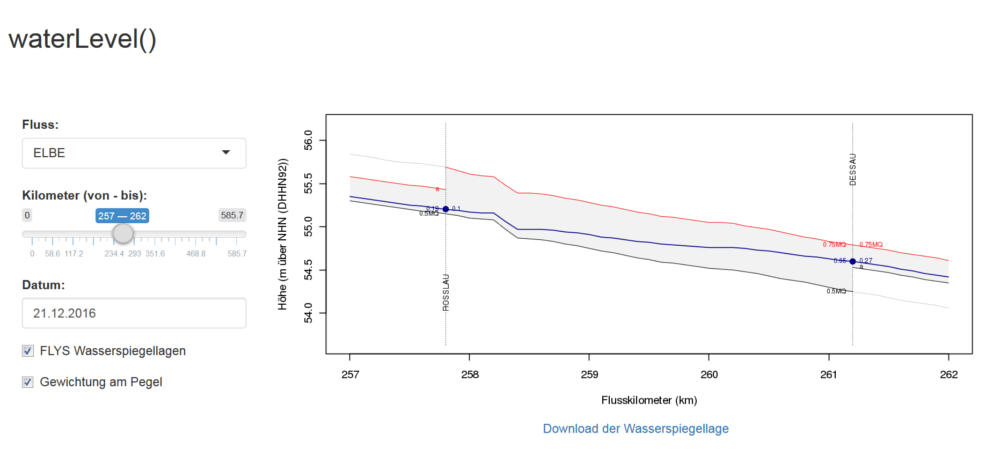

**Abb. 18**: Screenshot der [waterLevel-ShinyApp](https://shiny.bafg.de/waterlevel/) mit der interpolierten Wasserspiegellage, berechnungsrelevanten stationären [FLYS3](https://www.bafg.de/DE/5_Informiert/1_Portale_Dienste/FLYS/flys_node.html)-Wasserspiegellagen (**0.5MQ**, **a** und **0.75MQ**) und Wasserständen vom 21.12.2016 an der Elbe bei Rosslau und Dessau.

## waterLevelPegelonline

Ebenso verhält es sich mit der Funktion `waterLevelPegelonline()`. Da die Funktion die Pegeldaten auch noch über das Internet und nicht aus Paket-internen Daten bezieht, ist diese Applikation sehr gut geeignet aktuelle Wasserspiegelinformationen auf Anfrage zu generieren.

https://shiny.bafg.de/waterlevelpegelonline/

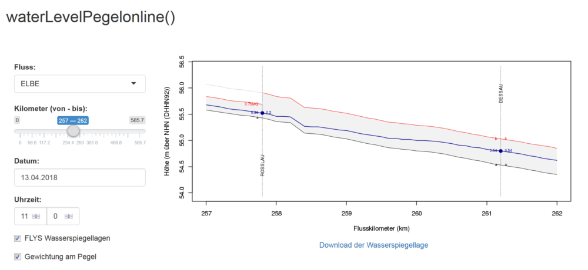

## hydflood (Überflutungsflächen und -dauern)

Durch Übertragung der Wasserspiegellagen entlang der Gewässerachse auf sogenannte Querprofilflächen lassen sich im GIS mittels des R-Paketes hydflood Überflutungsflächen, bzw. bei Betrachtung längerer Zeiträume auch Überflutungsdauern berechnen. Nähere Details zum Berechungsverfahren finden sich auf dem Dokumentationsportal von hydflood:

https://hydflood.bafg.de

# Literatur

Bundesanstalt für Gewässerkunde. (2013). FLYS goes WEB: Eröffnung eines neuen hydrologischen Fachdienstes in der BfG. Bundesanstalt für Gewässerkunde, Koblenz, Germany. https://doi.org/10.5675/BfG_Veranst_2013.4

Bundesanstalt für Gewässerkunde. (2016). FLYS – Flusshydrologischer Webdienst. Bundesanstalt für Gewässerkunde, Koblenz, Germany. https://www.bafg.de/DE/5_Informiert/1_Portale_Dienste/FLYS/flys_node.html

Busch, N., & Hammer, M. (2009). Einheitliche Grundlage für die Festlegung der Bemessungswasserspiegellagen der Elbe auf der frei fließenden Strecke in Deutschland. Bundesanstalt für Gewässerkunde, Koblenz, Germany. https://doi.org/10.5675/bfg-1650

DELTARES. (2018). SOBEK. https://download.deltares.nl/en/sobek/

HKV Hydrokontor. (2014). Erstellung eines SOBEK-River Modells für den Rhein von Iffezheim bis Pannerdense Kop als Weiterentwicklung bestehender SOBEK-RE Modelle. Aachen, Germany.

Rosenzweig, S., Giebel, H., & Schleuter, M. (2011). Ökologische Modellierungen für die Wasser- und Schifffahrtsverwaltung – Das integrierte Flussauenmodell INFORM in seiner neuesten Fassung (Version 3). Bundesanstalt für Gewässerkunde, Koblenz, Germany. https://doi.org/10.5675/bfg-1667